# Part I - Loan DataSet from Prosper Analysis

### 8. HOMEOWNERS?

**What is the Distribution of Loanees according to their homeownership Status?**

```python
data['IsBorrowerHomeowner'].value_counts()
```

```
True     57478
False    56459
Name: IsBorrowerHomeowner, dtype: int64
```

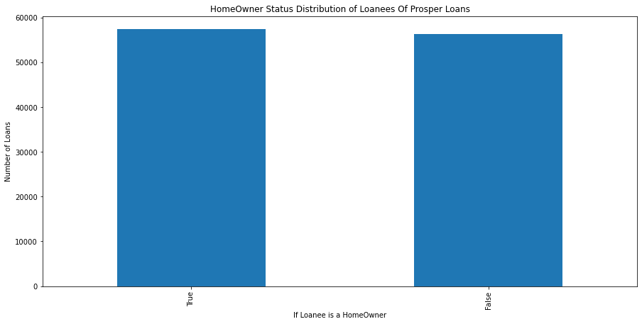

```python
univariate('IsBorrowerHomeowner', 'bar', 'HomeOwner Status Distribution of Loanees Of Prosper Loans', 'If Loanee is a HomeOwner', 'Number of Loans', 15, 7)
```

> **Observation**: From the above observation homeownership in individuals has no big difference when it comes to loan distribution in Prosper Loans. Loanee individuals who are home owners are slightly more than loanees who are not home owners.

## Bivariate Exploration

```python
data.sample(2)
```

|  | ListingKey | ListingNumber | ListingCreationDate | Term | LoanStatus | BorrowerAPR | BorrowerRate | ProsperScore | BorrowerState | Occupation | EmploymentStatus | EmploymentStatusDuration | IsBorrowerHomeowner | CurrentlyInGroup | TotalInquiries | DebtToIncomeRatio | IncomeRange | StatedMonthlyIncome | LoanOriginalAmount | Recommendations |
| --- | --- | --- | --- | --- | --- | --- | --- | --- | --- | --- | --- | --- | --- | --- | --- | --- | --- | --- | --- | --- |
| 44114 | EA553576095074851213999 | 749777 | 2013-04-11 11:52:36.183 | 36 | Current | 0.25781 | 0.2199 | 2.0 | MN | Professional | Employed | 22.0 | False | False | 3.0 | NaN | $75,000-99,999 | 6250.0 | 4000 | 0 |
| 103976 | 95F534164400076211715B0 | 292000 | 2008-03-11 20:01:32.377 | 36 | Completed | 0.14554 | 0.1420 | NaN | TX | Engineer - Chemical | Full-time | 159.0 | True | False | 3.0 | 0.14 | $50,000-74,999 | 5000.0 | 5000 | 0 |

### 1. NUMBER OF LOANS PER YEAR?

**What is the Distribution of Loans given out per year?**

```python
  def bivariate(column, kind, title, x, y, sizex, sizey):
    data[column].value_counts().plot(kind = kind,figsize=(sizex,sizey));
    plt.title(title)
    plt.xlabel(x)
    plt.ylabel(y)
```

> Let's create a Year and Month Column for further bivariate Analysis

```python
data['Year'] = data['ListingCreationDate'].dt.year
data['Month'] = data['ListingCreationDate'].dt.month
```

```python
data.head(1)
```

|  | ListingKey | ListingNumber | ListingCreationDate | Term | LoanStatus | BorrowerAPR | BorrowerRate | ProsperScore | BorrowerState | Occupation | ... | IsBorrowerHomeowner | CurrentlyInGroup | TotalInquiries | DebtToIncomeRatio | IncomeRange | StatedMonthlyIncome | LoanOriginalAmount | Recommendations | Year | Month |
| --- | --- | --- | --- | --- | --- | --- | --- | --- | --- | --- | --- | --- | --- | --- | --- | --- | --- | --- | --- | --- | --- |
| 0 | 1021339766868145413AB3B | 193129 | 2007-08-26 19:09:29.263 | 36 | Completed | 0.16516 | 0.158 | NaN | CO | Other | ... | True | True | 3.0 | 0.17 | $25,000-49,999 | 3083.333333 | 9425 | 0 | 2007 | 8 |

1 rows × 22 columns

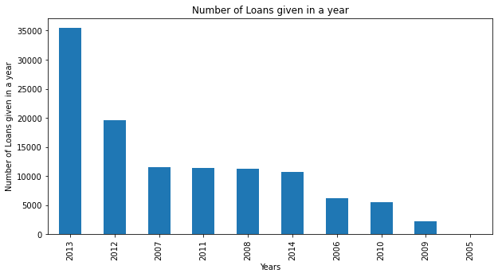

```python
bivariate('Year', 'bar','Number of Loans given in a year', 'Years', 'Number of Loans given in a year', 10, 5 )
```

> **Observation**: 2013 leads in the number of loans given out in a year, followed by 2012 while 2005 and 2009 have the least number of loans given out in a particular year.

### 2. NUMBER OF LOANS PER MONTH?

**What is the Distribution of Loans given out per month of every year?**

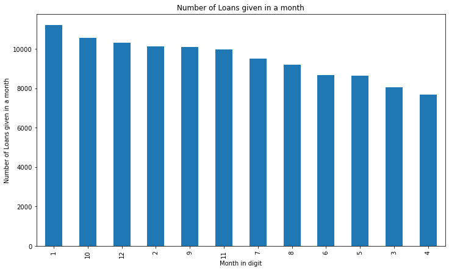

```python
bivariate('Month', 'bar','Number of Loans given in a month', 'Month in digit', 'Number of Loans given in a month', 12, 7 )
```

> **Observation**: Most Loans are taken in the month of January(1), followed by October(10) while March and April have the least number of Loans.

### 3. LOAN STATUS COMPARED PER LOAN TERMS?

**What is the Distribution of Loans Status for every term?**

```python
def term(column, duration, column2, kind, figx, figy):
    data[data[column] == duration].groupby([column, column2]).size().plot(kind=kind, figsize = (figx,figy));
```

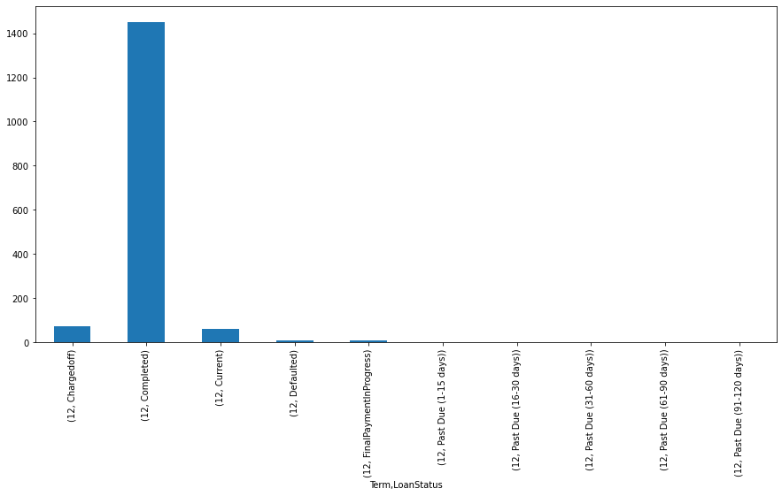

```python
term('Term', 12, 'LoanStatus', 'bar', 15, 7)
```

> **Observation**: Completed Status Loans are more in the 12 months term.

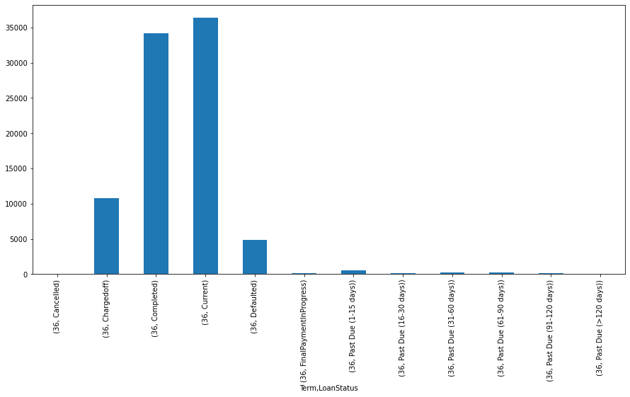

```python
term('Term', 36, 'LoanStatus', 'bar', 15, 7)
```

> **Observation**: More loans are in the current status for the 36 month loan term.

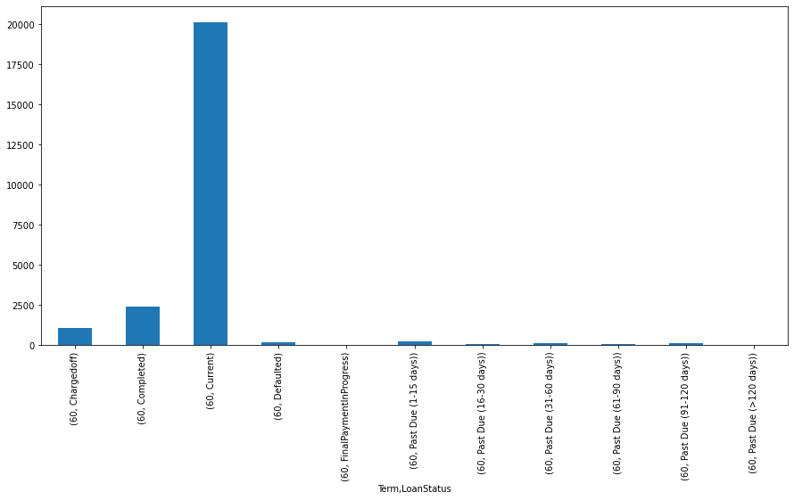

```python
term('Term', 60, 'LoanStatus', 'bar', 15, 7)
```

> **Observation**: More loans are prevalent in the current stage on the long term loans of 60 months.